# Demo: Learn Network Multi-Experiment Neural Spike Data

## random network case

Multi-experiment network estimation and inference (to be added) from neural spike train data

## Generate Spike Train Data

### Generate connectivity matrix

I created functions that generate both the connectivity matrix (3-dimensional (M,p,p) array) and the background rate (2-dimensional (M,p) array). I save those functions in **genSetting.py**

```python
import numpy as np
from genSetting import genRandomNetwork
print_max  = lambda x : np.round( np.max( abs(np.real(x) ) ) , 2)
```

```python
M = 3;  p = 50
Beta = np.zeros( (M, p, p) )
Beta[0]= genRandomNetwork( p=p, edge=0.3, sparsity=0.01, pos_rate=0.8)
Beta[1] = Beta[0]
Beta[2] = genRandomNetwork( p=p, edge=0.3, sparsity=0.01, pos_rate=0.8)

U = np.ones( (M, p) ) * 0.3

'max eigen value of Connectivity Matrix:', [print_max( Beta[m]) for m in range(M)]
```

```
('max eigen value of Connectivity Matrix:', [0.3, 0.3, 0.3])
```

### Visualize true network structures

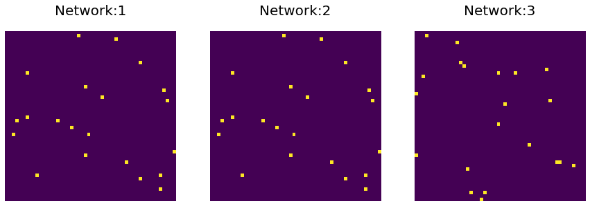

```python
import matplotlib.pyplot as plt

fig, axs = plt.subplots(1, 3,figsize=(15,45))
for m in range(M):
    axs[m].axis('off')
    axs[m].matshow(Beta[m]!=0)
    axs[m].set_title('Network:'+ str(m+1) ,fontsize=20)
```

### Generate spike train data

Given the connectivity matrix and the background intensity rate as inputs, I generate spike train data from p processes under M experiment. The function **simu_net** is saved in **simu_net.py**

```python
from simu_net import simu_net
T = [1000,1000,1000] # [200,500,300] #
rho, rate, lag = 2, 1, 1
M = Beta.shape[0]
p = Beta.shape[1]

np.random.seed(123)
DATA = simu_net( T, # length of each experiment, array of length M
                M, # no. experiments
                p, # no. processes
                Beta, U, # connectivity matrix and the background intensity rate
                rho , rate, lag # parameter used for transition kernel
               )
Spike = DATA['Spike'] # output Spike, the spike train data, is a dictionary of length M with its value a p x p matrix
Phi = DATA['Phi'] # output Phi, the transition matrix, is a dictionary of length M with its value a p x p matrix
```

## Estimate Multi-Experiment Networks

The key function, **net_est**, for multi-experiment network estimation are saved in **net_est.py**. The function repeatedly calls the general lasso solver (see function **spg_genlasso**). Besides the key input of the spike train data (dictionary format), **net_est** requires input of similarity matrix, **W**, and the transition matrix, **X**. **net_est** outputs the estimated connectivity matrix and background intensity.

If **W** is None, the default is to get empirical cross-correlation based similarity matrix (by calling function **getW**). If **X** is None, the default is to calcualte the transition matrix using function **getX**.

```python
from net_est_auto import *
```

### Joint estimation using informative similarity weights (default)

In this part, we call **net_est** to jointly estimate networks under all experiments. By giving **W** calculated from the cross-correlations, and setting up property tuning parameter values for the fusion penalty, **lam2**, the function estimate the networks jointly.

### Tunig parameter auto-selected based on eBIC

```python
EST_ALL = net_est( Y=Spike,# outcome, dict, each  T x p array
                #  X = None ,  # optional, design matrix , dict, if not given, generated with exponetial decay
                #  method = 'joint',#optional, default, joint est with informative weights
                #  W = None ,  # optional, weight matrix, if not given, generate empirical informative weights
                # lams = lams # optional, if not specified, auto select based on eBIC
                #  beta_init ,   # optional, initial coef values, default 0s
                #  eps, # optional: error of smoothing approxiamtion, default, 1e-4
                # max_iter, #optional: maximum iterations , default 1e4
                # tol , # optional: tolerance level of convergence, default, 1e-5
                # msg # optional: print convergence iterations, default, False  ,
            )

BETA_EST = EST_ALL['BETA_EST']
U_EST = EST_ALL['U_EST']
lam_opt = EST_ALL['lam_opt']
```

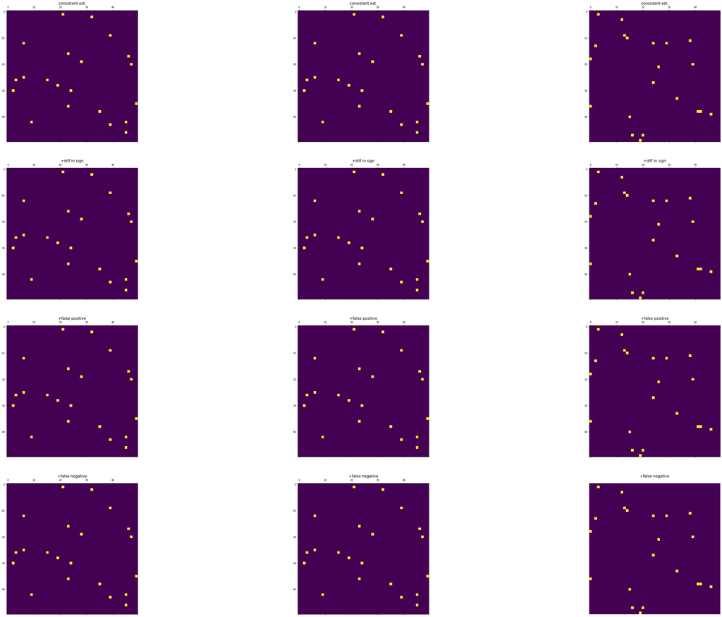

```python
# plot estimated connectivity matrix

fig, axs = plt.subplots(4, 3,figsize=(60,45))
plt.axis('off')
for m in range(M):

    BETA_PLOT = np.zeros( (p,p))

    idx =  BETA_EST[m] * Beta[m] > 0 # consistent edge
    BETA_PLOT[idx] = 1
    axs[0,m].matshow( BETA_PLOT )
    axs[0,m].set_title('consistent est.', fontsize=15)
    #print(np.sum(idx) )

    idx =  BETA_EST[m] * Beta[m]  < 0 # differ in sign
    BETA_PLOT[ idx ] = - 1
    axs[1,m].matshow( BETA_PLOT )
    axs[1,m].set_title('+diff in sign', fontsize=15)
    #print(np.sum(idx) )

    idx =   (BETA_EST[m]!=0) *   (Beta[m]==0)  # false discovery
    BETA_PLOT[ idx  ] = - 1
    axs[2,m].matshow( BETA_PLOT )
    axs[2,m].set_title('+false positive', fontsize=15)
    #print(np.sum(idx!=0) )

    idx =   (BETA_EST[m]==0) *   (Beta[m]!=0)  # mis discovery
    BETA_PLOT[ idx  ] = - 1
    axs[3,m].matshow( BETA_PLOT )
    axs[3,m].set_title('+false negative', fontsize=15)
    #print(np.sum(idx!=0) )


    #axs[m].set_title('Est. Network:'+ str(m+1) ,fontsize=20)
```

### Separate estimation

**net_est** also allows separate estimation -- that is estimating each network using its own data.

```python
EST = net_est( Y=Spike, method = 'separate' )

BETA_EST = EST['BETA_EST']
U_EST = EST['U_EST']
```

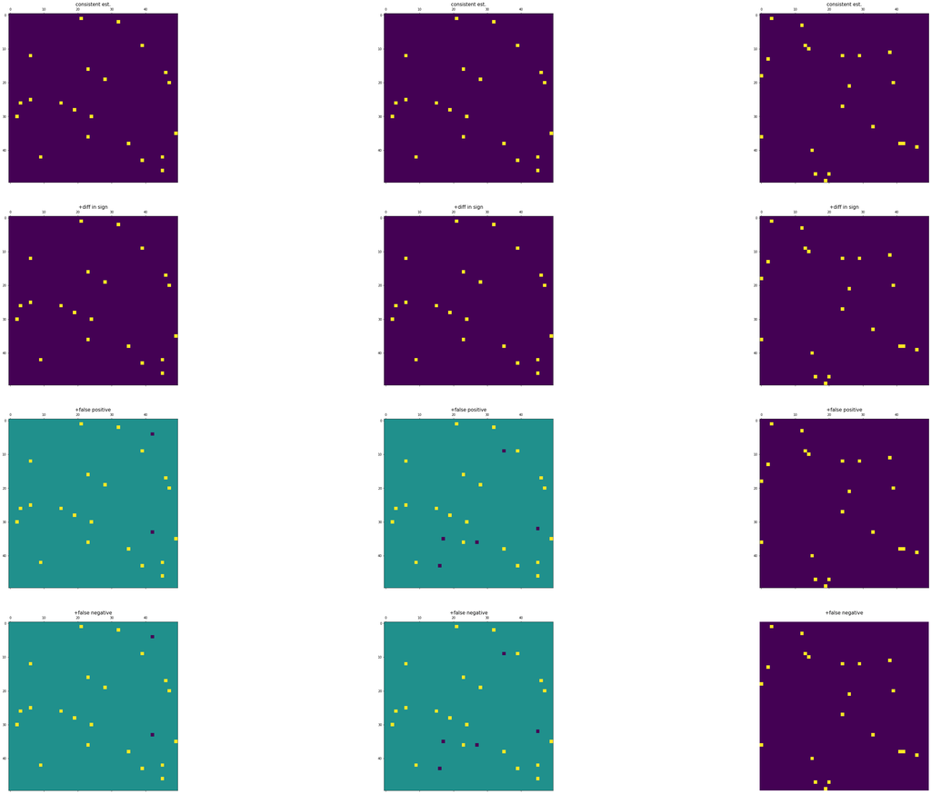

```python
# plot estimated connectivity matrix

fig, axs = plt.subplots(4, 3,figsize=(60,45))
plt.axis('off')
for m in range(M):

    BETA_PLOT = np.zeros( (p,p))

    idx =  BETA_EST[m] * Beta[m] > 0 # consistent edge
    BETA_PLOT[idx] = 1
    axs[0,m].matshow( BETA_PLOT )
    axs[0,m].set_title('consistent est.', fontsize=15)
    #print(np.sum(idx) )

    idx =  BETA_EST[m] * Beta[m]  < 0 # differ in sign
    BETA_PLOT[ idx ] = - 1
    axs[1,m].matshow( BETA_PLOT )
    axs[1,m].set_title('+diff in sign', fontsize=15)
    #print(np.sum(idx) )

    idx =   (BETA_EST[m]!=0) *   (Beta[m]==0)  # false discovery
    BETA_PLOT[ idx  ] = - 1
    axs[2,m].matshow( BETA_PLOT )
    axs[2,m].set_title('+false positive', fontsize=15)
    #print(np.sum(idx!=0) )

    idx =   (BETA_EST[m]==0) *   (Beta[m]!=0)  # mis discovery
    BETA_PLOT[ idx  ] = - 1
    axs[3,m].matshow( BETA_PLOT )
    axs[3,m].set_title('+false negative', fontsize=15)
    #print(np.sum(idx!=0) )


    #axs[m].set_title('Est. Network:'+ str(m+1) ,fontsize=20)
```

### Joint Estimation using uniform weights

As a comparison, **net_est** also allows joint estimation using uniform weights. To do this, we first construct uniform weight matrix, then we estimate the network jointly.

```python
EST = net_est( Y=Spike, method = 'uniform'      )

BETA_EST = EST['BETA_EST']
U_EST = EST['U_EST']
```

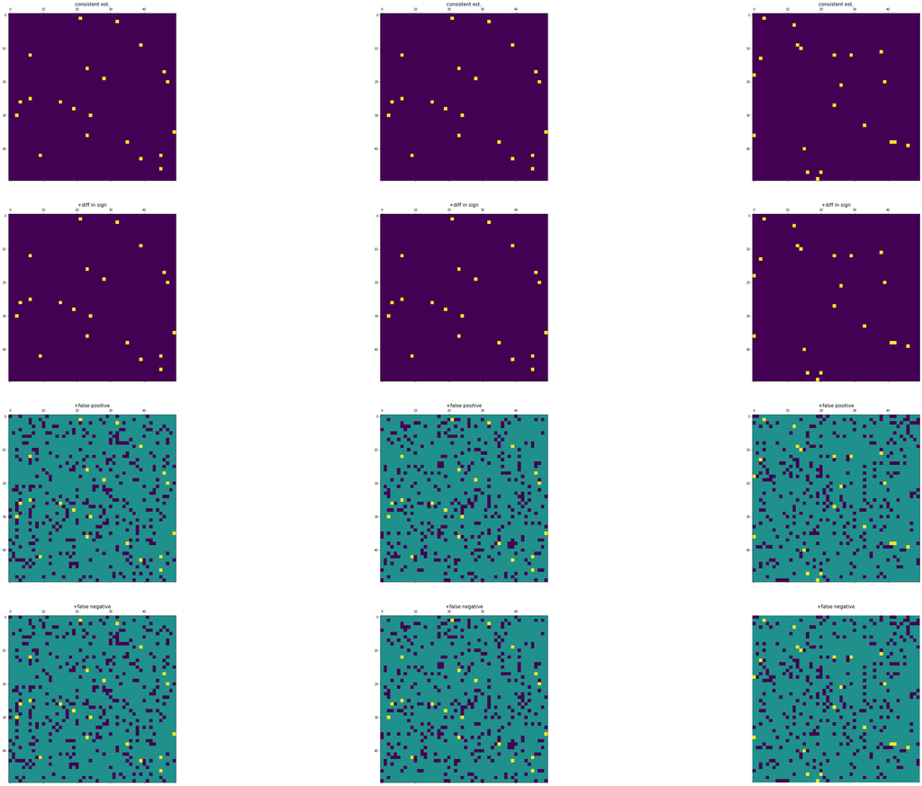

```python
# plot estimated connectivity matrix

fig, axs = plt.subplots(4, 3,figsize=(60,45))
plt.axis('off')
for m in range(M):

    BETA_PLOT = np.zeros( (p,p))

    idx =  BETA_EST[m] * Beta[m] > 0 # consistent edge
    BETA_PLOT[idx] = 1
    axs[0,m].matshow( BETA_PLOT )
    axs[0,m].set_title('consistent est.', fontsize=15)
    #print(np.sum(idx) )

    idx =  BETA_EST[m] * Beta[m]  < 0 # differ in sign
    BETA_PLOT[ idx ] = - 1
    axs[1,m].matshow( BETA_PLOT )
    axs[1,m].set_title('+diff in sign', fontsize=15)
    #print(np.sum(idx) )

    idx =   (BETA_EST[m]!=0) *   (Beta[m]==0)  # false discovery
    BETA_PLOT[ idx  ] = - 1
    axs[2,m].matshow( BETA_PLOT )
    axs[2,m].set_title('+false positive', fontsize=15)
    #print(np.sum(idx!=0) )

    idx =   (BETA_EST[m]==0) *   (Beta[m]!=0)  # mis discovery
    BETA_PLOT[ idx  ] = - 1
    axs[3,m].matshow( BETA_PLOT )
    axs[3,m].set_title('+false negative', fontsize=15)
    #print(np.sum(idx!=0) )


    #axs[m].set_title('Est. Network:'+ str(m+1) ,fontsize=20)
```